# Week 9 / Exploratory Data Analysis, Base Graphics, Lab 06

AG Schissler

Monday October 21, 2019

## I. Opening

### I. Start-of-class work

1. Log in the your workstation.
2. Open the RStudio application on your machine.
3. Open 16_base_graphics_startLab06.Rmd from website so that you can work along the lecture.
4. Open lab_06_base_graphics.Rmd to have the lab available.

### This week’s agenda

- Continue *Working with data* Unit II.
- Focus on using R to plot data to conduct exploratory data analysis (EDA).

### Today learning outcomes

Students will be able to

- use base R graphics to plot data

## II. Introduction to base graphics in R

Base graphics refers to the automatically loaded `graphics` and `base` R packages. These plots are typically less vizually appealing that `ggplot2` plots and use a different syntax. But the base features are surprisingly flexible and powerful. I use base graphics to quickly plot during EDA, using commands such as `plot()` and `hist()`.

## III. Using base graphics

### Plotting in R

Base R has a set of powerful plotting tools. An overview:

- `plot()`: generic plotting function
- `points()`: add points to an existing plot
- `lines()`, `abline()`: add lines to an existing plot
- `text()`, `legend()`: add text to an existing plot
- `rect()`, `polygon()`: add shapes to an existing plot
- `hist()`, `image()`: histogram and heatmap
- `heat.colors()`, `topo.colors()`, etc: create a color vector
- `density()`: estimate density, which can be plotted
- `contour()`: draw contours, or add to existing plot
- `curve()`: draw a curve, or add to existing plot

### Scatter plot

To make a scatter plot of one variable versus another, use `plot()`

```r
n = 50
set.seed(0)
x = sort(runif(n, min=-2, max=2))
y = x^3 + rnorm(n)
plot(x, y)
```

### Plot type

The `type` argument controls the plot type. Default is `p` for points; set it to `l` for lines

```r
plot(x, y, type="p")
```

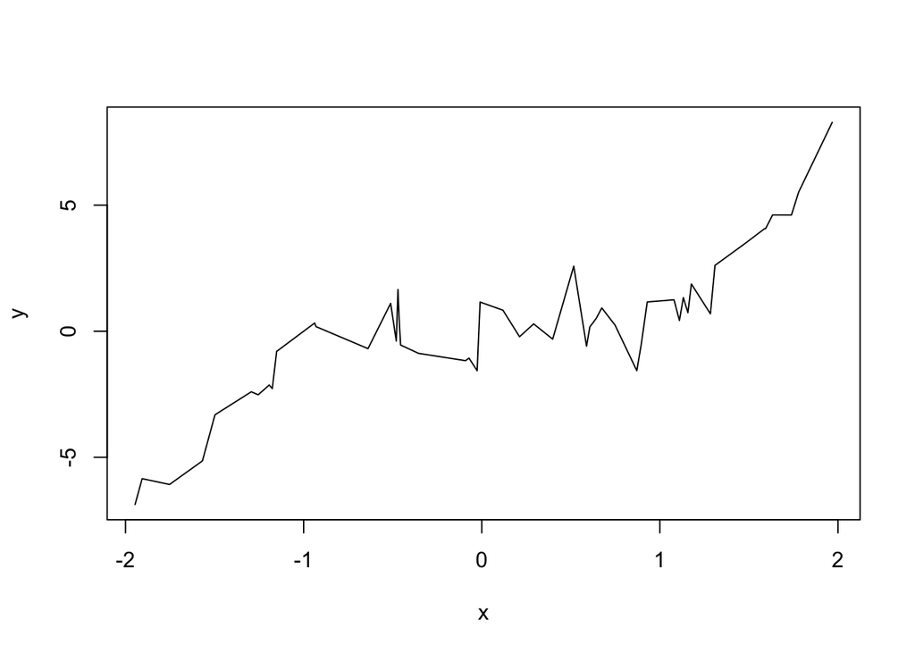

```r
plot(x, y, type="l")
```

Try also `b` or `o`, for both points and lines

### Labels

The `main` argument controls the title; `xlab` and `ylab` are the x and y labels

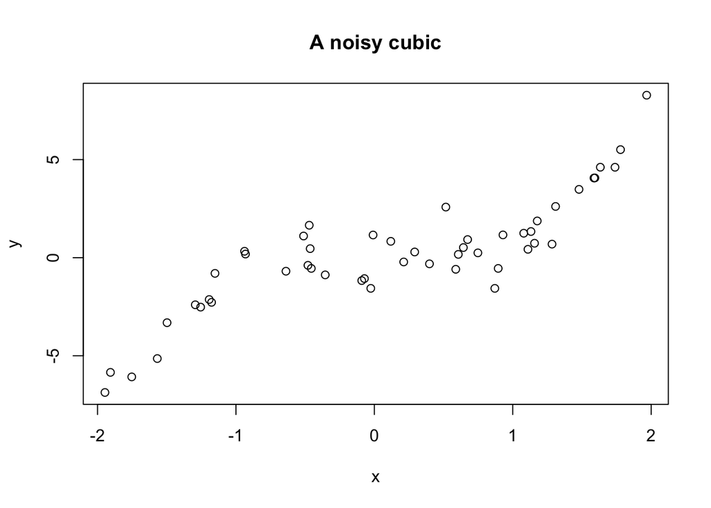

```r
plot(x, y, main="A noisy cubic") # Note the default x and y labels
```

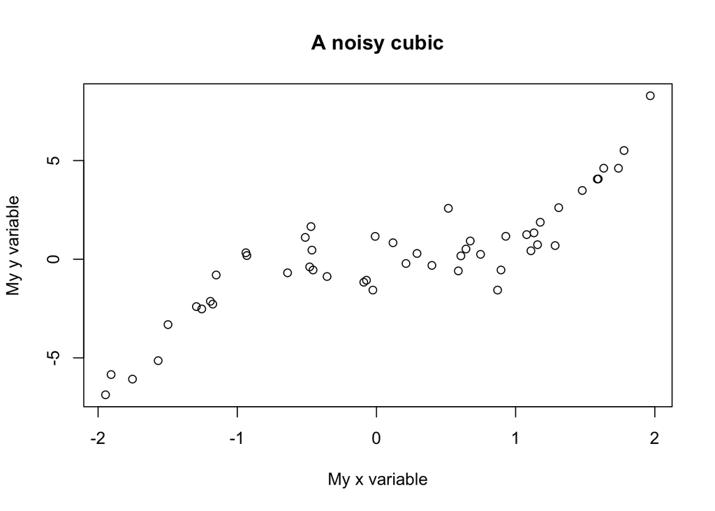

```r
plot(x, y, main="A noisy cubic", xlab="My x variable", ylab="My y variable")
```

### Point type

Use the `pch` argument to control point type

```r
plot(x, y, pch=21) # Empty circles, default
```

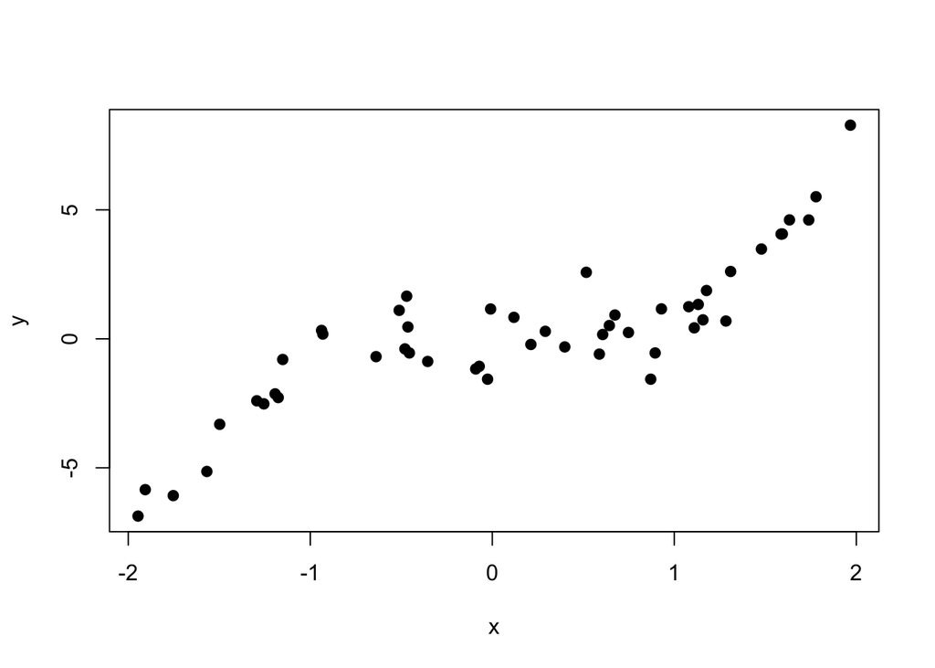

```r
plot(x, y, pch=19) # Filled circles
```

Try also `20` for small filled circles, or `"."` for single pixels

### Line type

Use the `lty` argument to control the line type, and `lwd` to control the line width

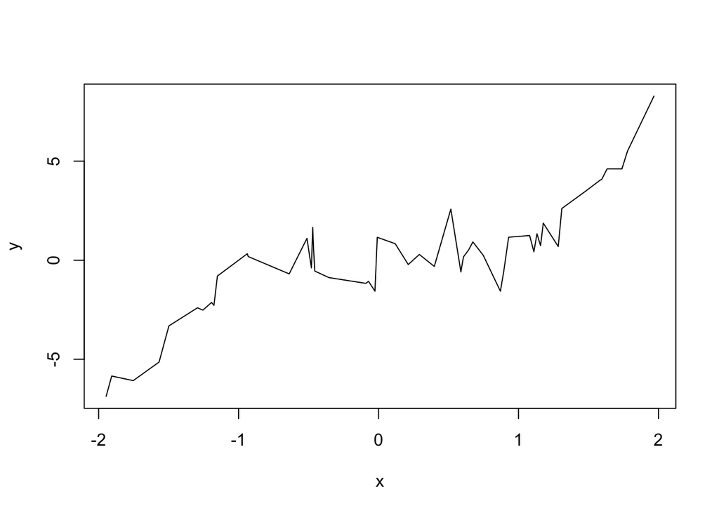

```r
plot(x, y, type="l", lty=1, lwd=1) # Solid line, default width
```

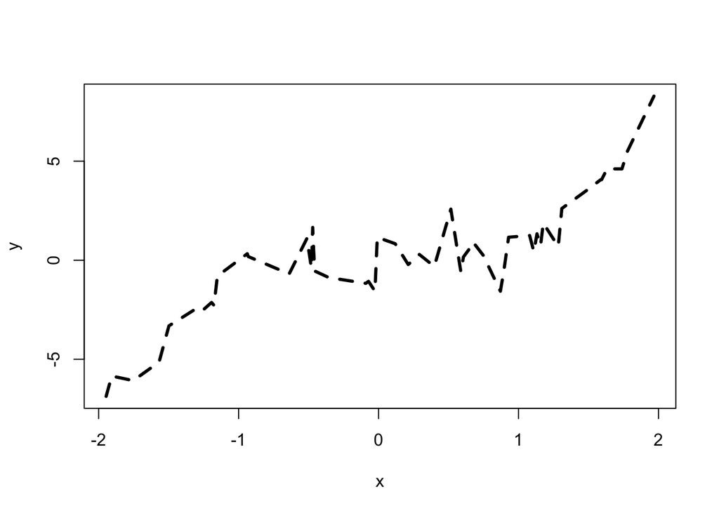

```r
plot(x, y, type="l", lty=2, lwd=3) # Dashed line, 3 times as thick
```

### Color

Use the `col` argument to control the color. Can be:

- An integer between 1 and 8 for basic colors
- A string for any of the 657 available named colors

The function `colors()` returns a string vector of the available colors

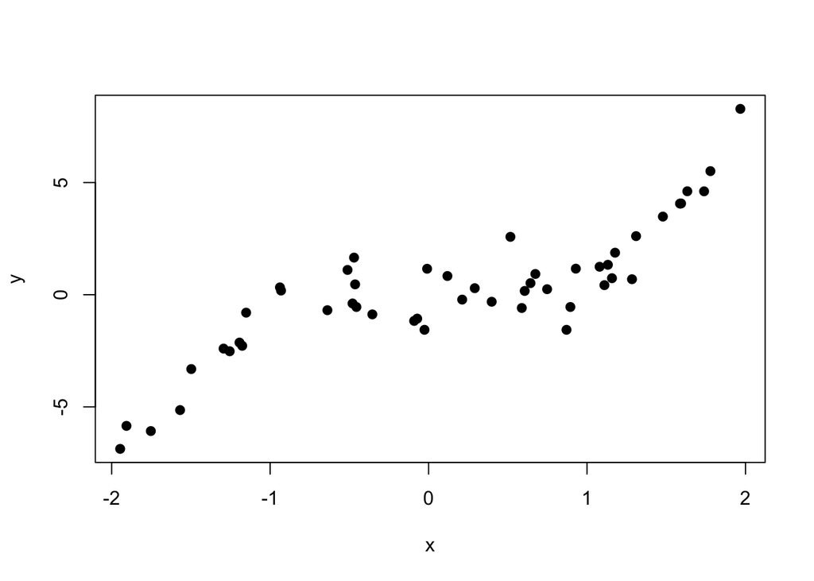

```r
plot(x, y, pch=19, col=1) # Black, default
```

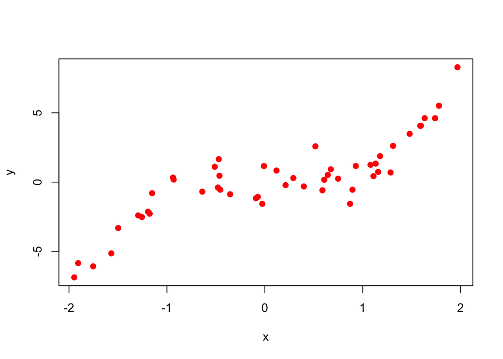

```r
plot(x, y, pch=19, col=2) # Red
```

### Multiple plots

To set up a plotting grid of arbitrary dimension, use the `par()` function, with the argument `mfrow`. Note: in general this will affect all following plots! (Except in separate R Markdown code chunks …)

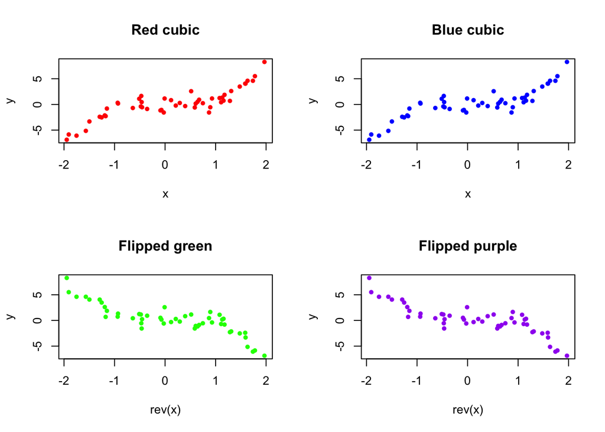

```r
par(mfrow=c(2,2)) # Grid elements are filled by row
plot(x, y, main="Red cubic", pch=20, col="red")
plot(x, y, main="Blue cubic", pch=20, col="blue")
plot(rev(x), y, main="Flipped green", pch=20, col="green")
plot(rev(x), y, main="Flipped purple", pch=20, col="purple")
```

### Margin

Default margins in R are large (and ugly); to change them, use the `par()` function, with the argument `mar`. Note: in general this will affect all following plots! (Except in separate R Markdown code chunks …)

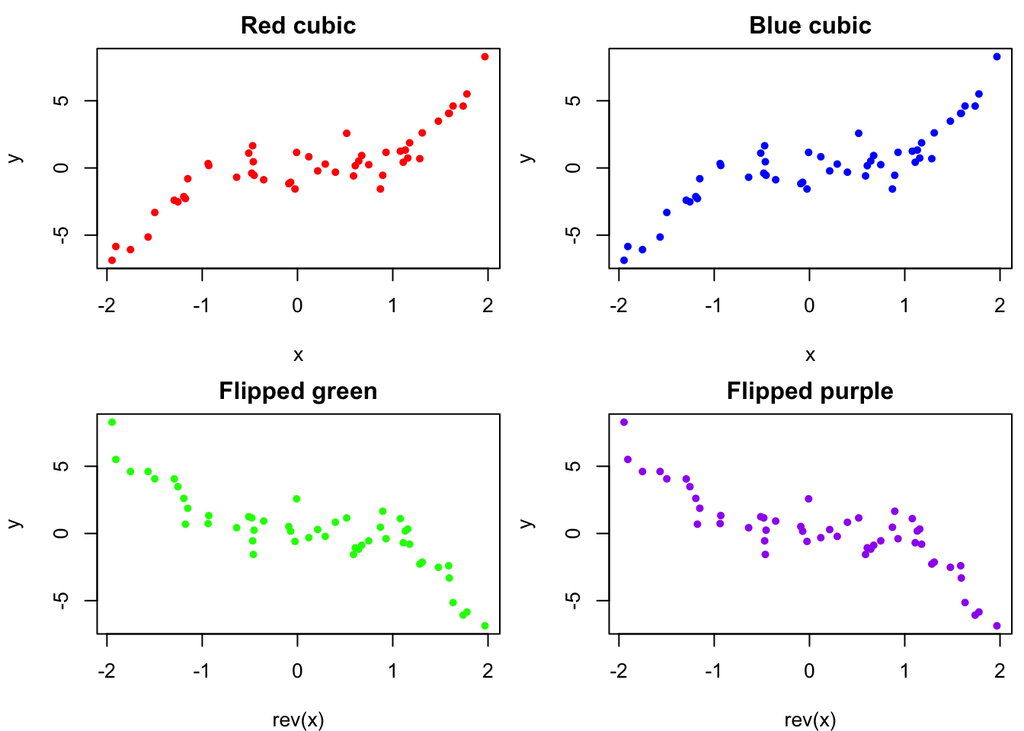

```r
par(mfrow=c(2,2), mar=c(4,4,2,0.5))
plot(x, y, main="Red cubic", pch=20, col="red")
plot(x, y, main="Blue cubic", pch=20, col="blue")
plot(rev(x), y, main="Flipped green", pch=20, col="green")
plot(rev(x), y, main="Flipped purple", pch=20, col="purple")
```

```r
# Evidence that par() does not carry over to separate R Markdown code chunks
plot(x, y)
```

### Saving plots

Use the `pdf()` function to save a pdf file of your plot, in your R working directory. Use `getwd()` to get the working directory, and `setwd()` to set it

```r
getwd() # This is where the pdf will be saved
```

```
## [1] "/Users/alfred/OneDrive - University of Nevada, Reno/Teaching/STAT_445-645/git_public/meeting_agendas"
```

```r
pdf(file="assets/noisy_cubics.pdf", height=7, width=7) # Height, width are in inches
par(mfrow=c(2,2), mar=c(4,4,2,0.5))
plot(x, y, main="Red cubic", pch=20, col="red")
plot(x, y, main="Blue cubic", pch=20, col="blue")
plot(rev(x), y, main="Flipped green", pch=20, col="green")
plot(rev(x), y, main="Flipped purple", pch=20, col="purple")
graphics.off()
```

Also, use the `jpg()` and `png()` functions to save jpg and png files

### Adding to plots

The main tools for this are:

- `points()`: add points to an existing plot
- `lines()`, `abline()`: add lines to an existing plot
- `text()`, `legend()`: add text to an existing plot
- `rect()`, `polygon()`: add shapes to an existing plot

You’ll get practice with this on lab/hw. Pay attention to **layers**—they work just like they would if you were painting a picture by hand.

## *Histograms and heatmaps*

#### Plotting a histogram

To plot a histogram of a numeric vector, use `hist()`

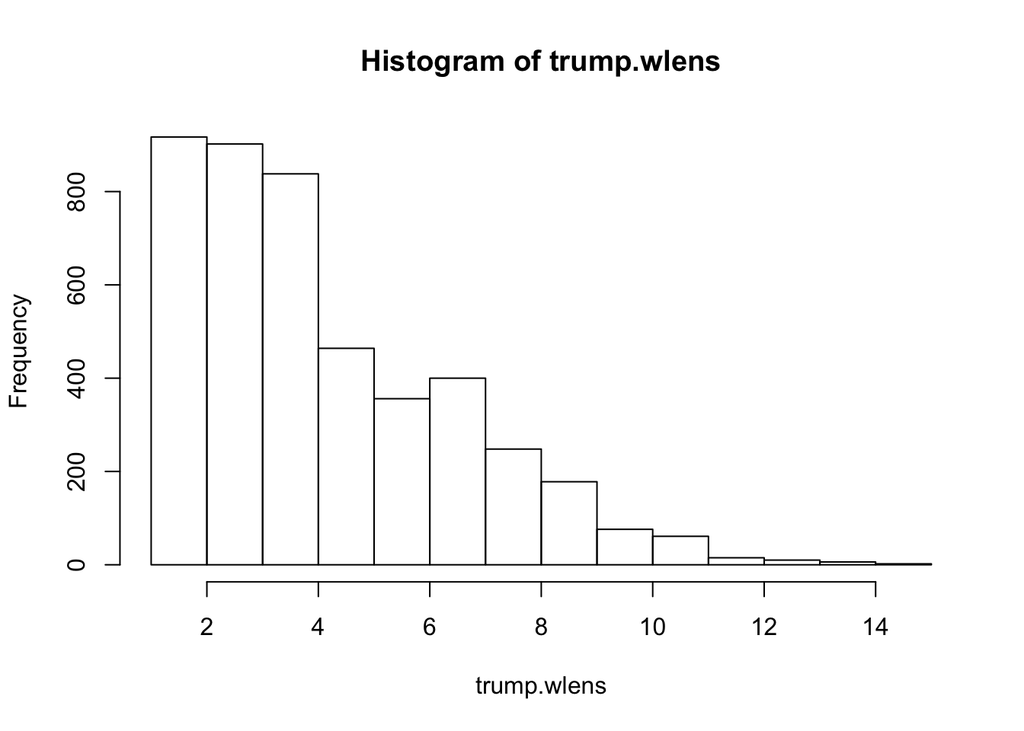

```r
trump.lines =
  readLines("http://www.stat.cmu.edu/~ryantibs/statcomp/data/trump.txt")
trump.words = strsplit(paste(trump.lines, collapse=" "),
                       split="[[:space:]]|[[:punct:]]")[[1]]
trump.words = tolower(trump.words[trump.words != ""])
trump.wlens = nchar(trump.words)
hist(trump.wlens)
```

### Histogram options

Several options are available as arguments to `hist()`, such as `col`, `freq`, `breaks`, `xlab`, `ylab`, `main`

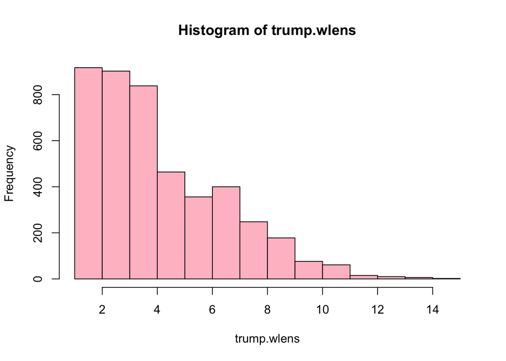

```r
hist(trump.wlens, col="pink", freq=TRUE) # Frequency scale, default
```

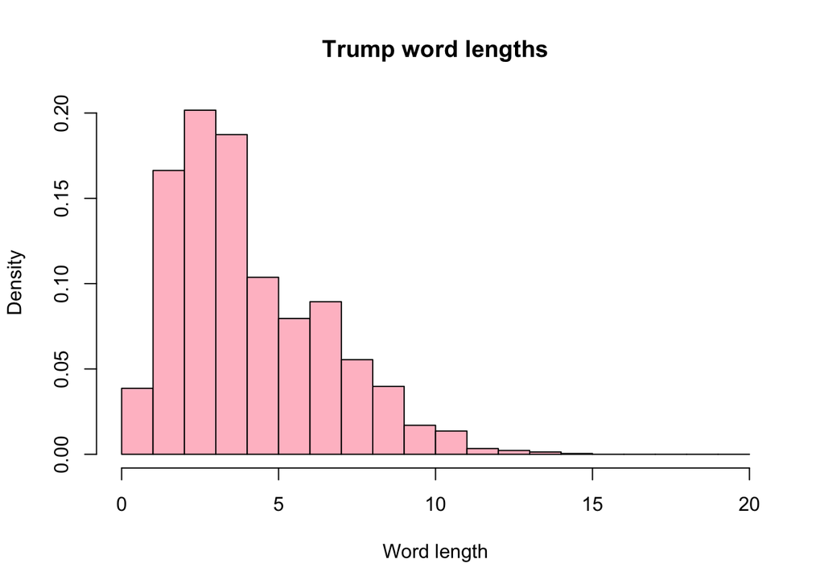

```r
hist(trump.wlens, col="pink", freq=FALSE, # Probability scale, and more options
     breaks=0:20, xlab="Word length", main="Trump word lengths")
```

### Adding a histogram to an existing plot

To add a histogram to an existing plot (say, another histogram), use `hist()` with `add=TRUE`

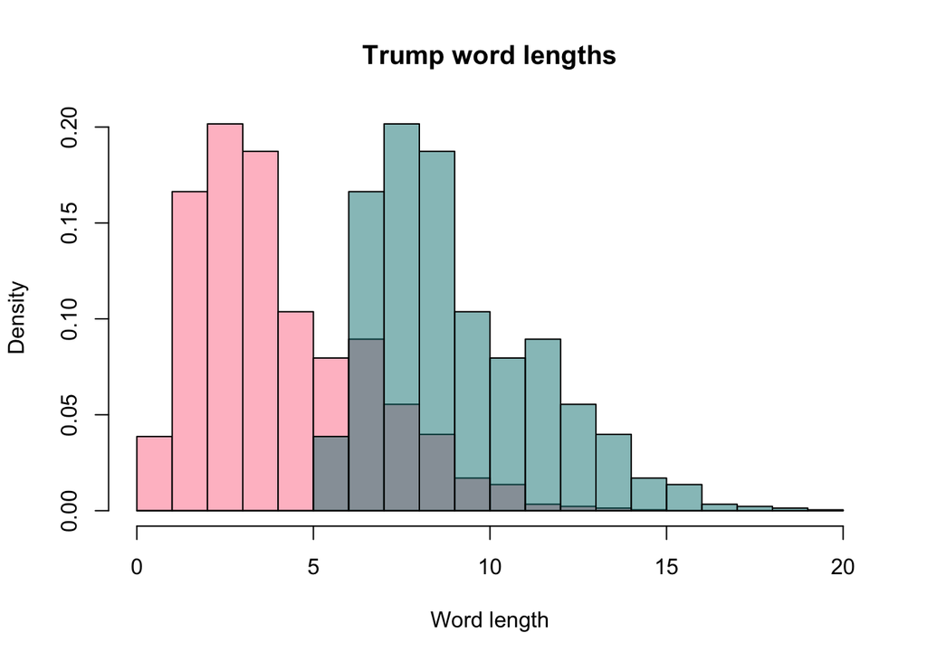

```r
hist(trump.wlens, col="pink", freq=FALSE, breaks=0:20,
     xlab="Word length", main="Trump word lengths")
hist(trump.wlens + 5, col=rgb(0,0.5,0.5,0.5), # Note: using a transparent color
     freq=FALSE, breaks=0:20, add=TRUE)
```

### Adding a density curve to a histogram

To estimate a density from a numeric vector, use `density()`. This returns a list; it has components `x` and `y`, so we can actually call `lines()` directly on the returned object

```r
density.est = density(trump.wlens, adjust=1.5) # 1.5 times the default bandwidth
class(density.est)
```

```
## [1] "density"
```

```r
names(density.est)
```

```
## [1] "x"         "y"         "bw"        "n"         "call"      "data.name"
## [7] "has.na"
```

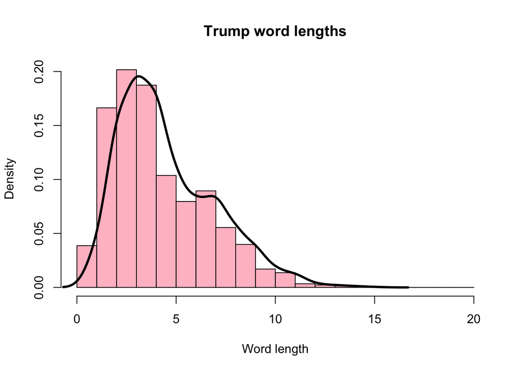

```r
hist(trump.wlens, col="pink", freq=FALSE, breaks=0:20,
     xlab="Word length", main="Trump word lengths")
lines(density.est, lwd=3)
```

### Plotting a heatmap

To plot a heatmap of a numeric matrix, use `image()`

```r
(mat = 1:5 %o% 6:10) # %o% gives for outer product
```

```
##      [,1] [,2] [,3] [,4] [,5]
## [1,]    6    7    8    9   10
## [2,]   12   14   16   18   20
## [3,]   18   21   24   27   30
## [4,]   24   28   32   36   40
## [5,]   30   35   40   45   50
```

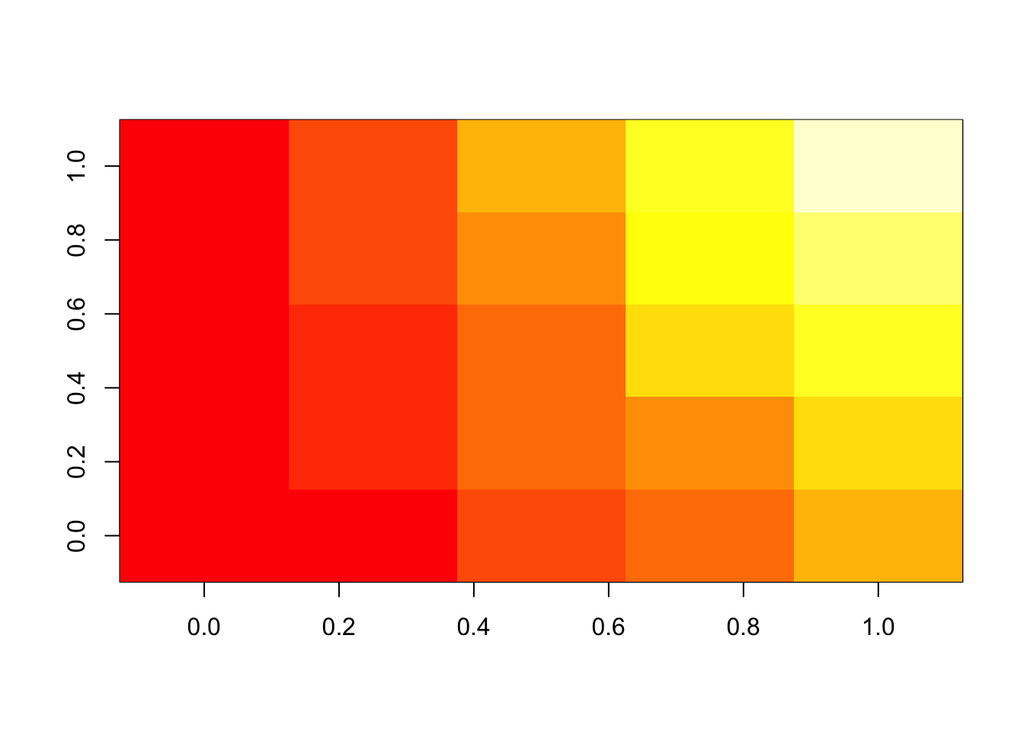

```r
image(mat) # Red means low, white means high
```

### Orientation of `image()`

The orientation of `image()` is to plot the heatmap according to the following order, in terms of the matrix elements:

$$\begin{array}{cccc}
(1,\text{ncol}) & (2, \text{ncol}) & \ldots & (\text{nrow},\text{ncol}) \\
\vdots & & & \\
(1,2) & (2,2) & \ldots & (\text{nrow},2) \\
(1,1) & (2,1) & \ldots & (\text{nrow},1)
\end{array}$$

This is a *90 degrees counterclockwise* rotation of the “usual” printed order for a matrix:

$$\begin{array}{cccc}
(1,1) & (1,2) & \ldots & (1,\text{ncol}) \\
(2,1) & (2,2) & \ldots & (2,\text{ncol}) \\
\vdots & & & \\
(\text{nrow},1) & (\text{nrow},2) & \ldots & (\text{nrow},\text{ncol})
\end{array}$$

Therefore, if you want the displayed heatmap to follow the usual order, you must rotate the matrix *90 degrees clockwise* before passing it in to `image()`. (Equivalently: reverse the row order, then take the transpose.) Convenient way of doing so:

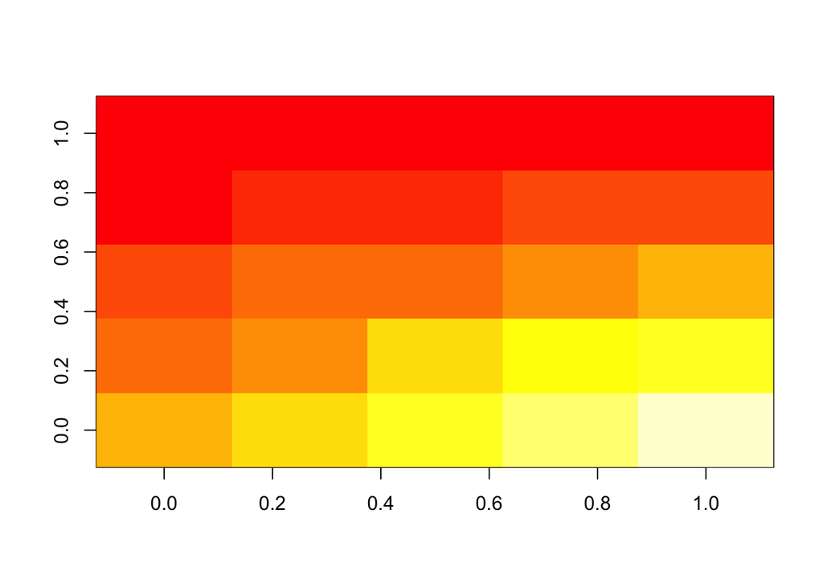

```r
clockwise90 = function(a) { t(a[nrow(a):1,]) } # Handy rotate function
image(clockwise90(mat))
```

### Color scale

The default is to use a red-to-white color scale in `image()`. But the `col` argument can take any vector of colors. Built-in functions `gray.colors()`, `rainbow()`, `heat.colors()`, `topo.colors()`, `terrain.colors()`, `cm.colors()` all return continguous color vectors of given length

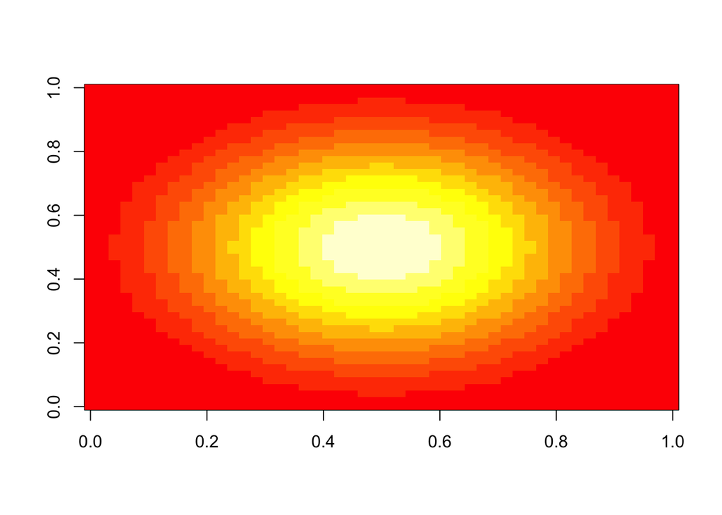

```r
phi = dnorm(seq(-2,2,length=50))
normal.mat = phi %o% phi
image(normal.mat) # Default is col=heat.colors(12)
```

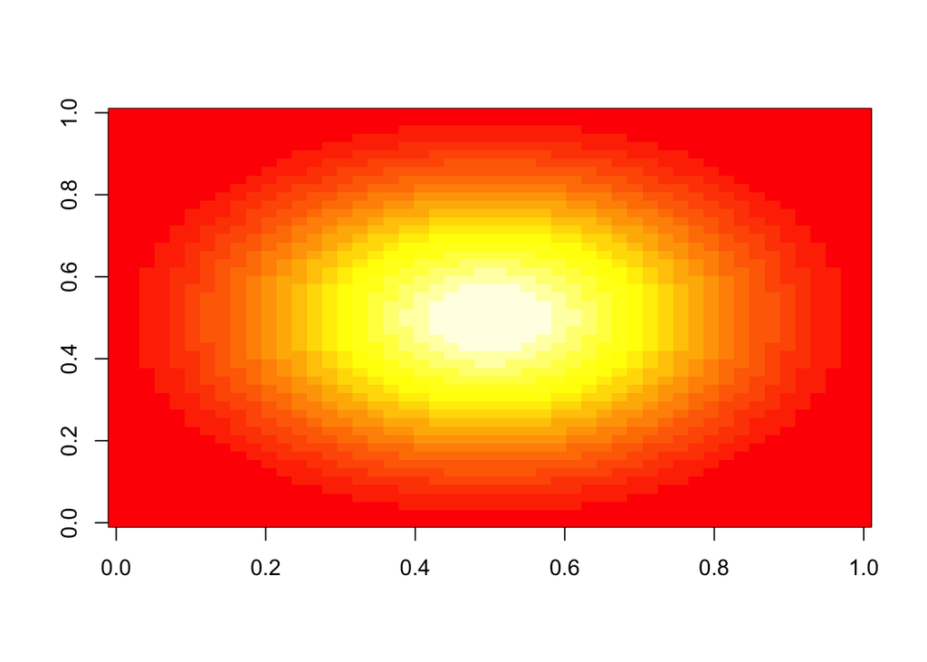

```r
image(normal.mat, col=heat.colors(20)) # More colors
```

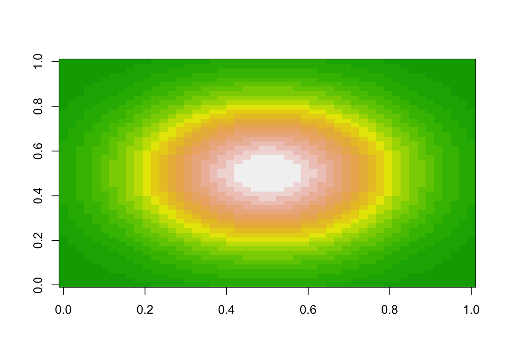

```r
image(normal.mat, col=terrain.colors(20)) # Terrain colors
```

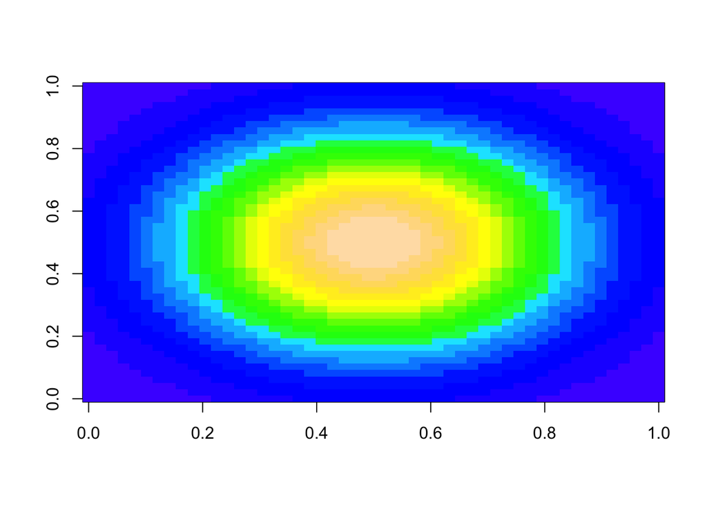

```r
image(normal.mat, col=topo.colors(20)) # Topological colors
```

### Drawing contour lines

To draw contour lines from a numeric matrix, use `contour()`; to add contours to an existing plot (like, a heatmap), use `contour()` with `add=TRUE`

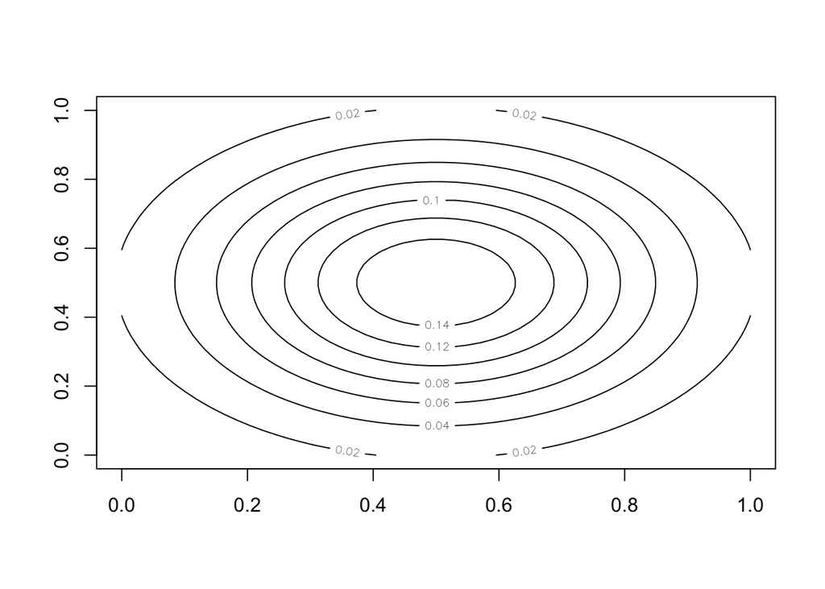

```r
contour(normal.mat)
```

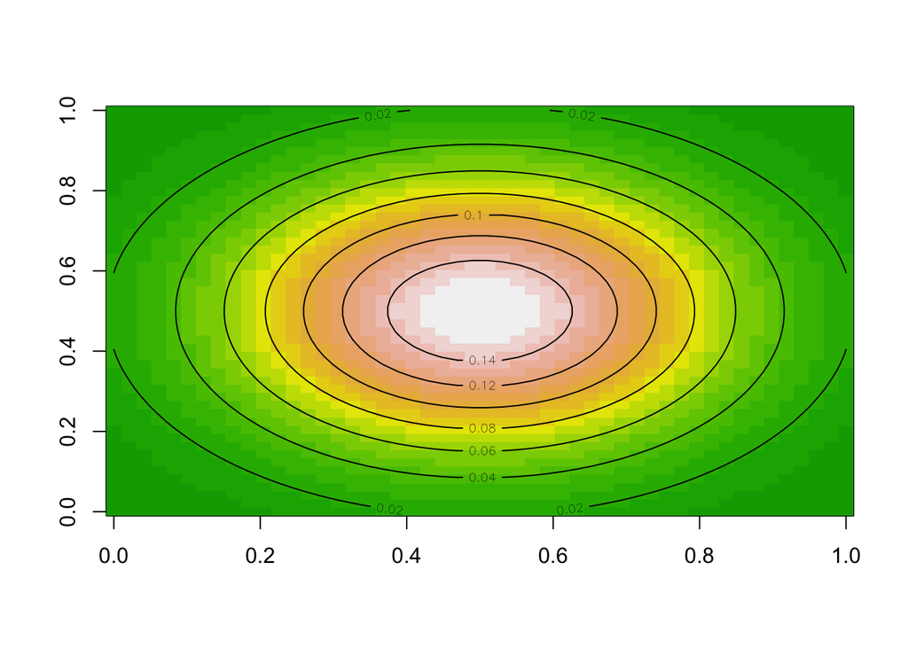

```r
image(normal.mat, col=terrain.colors(20))
contour(normal.mat, add=TRUE)
```

### Summary

- `plot()`: generic plotting function
- `points()`: add points to an existing plot
- `lines()`, `abline()`: add lines to an existing plot
- `text()`, `legend()`: add text to an existing plot
- `rect()`, `polygon()`: add shapes to an existing plot
- `hist()`, `image()`: histogram and heatmap
- `heat.colors()`, `topo.colors()`, etc: create a color vector
- `density()`: estimate density, which can be plotted
- `contour()`: draw contours, or add to existing plot

## IV. Begin Lab 06

### Some suggested steps

1. Review the entire document, estimate time to complete.
2. Ask for clarification as needed.
3. Identify next actions.
4. Schedule time to finish on time.

## V. Summary

What was your favorite `base` plotting feature or plot? Why?